# Final Presentation: Group 1

2025-05-14

## Research Question

- How do squirrel-human interactions differ across various NYC parks?
  - Interested in environmental and atmosphere/ambiance factors
  - Squirrels are important part of the NYC ecosystem & health of urban green spaces
- Our hypothesis: Busier parks will have braver squirrels!
  - Adaptation from exposure

## Our Dataset

- Dataset source: The Squirrel Census sample from March 1st, 2020
- 3 Datasets: Park dataset, Squirrel dataset, & Park Info dataset (NYCgovparks.org, made by us)
  - Left-joined by common variables (area name, area ID, park name, and park ID)
- Cleaned data mainly using grepl() function
  - for some variables, people were allowed to write additional comments

## Our Dataset (cont.)

- Park Dataset:
  - Park conditions (boolean: calm or busy)
  - Area name: area where the park is located (upper manhattan, central manhattan, lower manhattan, or brooklyn)
  - Area ID: A, B, C, or D assigned to an area name
  - Park name: name of the park
  - Park ID: 1-24 assigned to park names
  - Number of squirrels: squirrel count at specific park
  - Litter (some, none, abundant)

## Our Dataset (cont.)

- Squirrel Dataset:
  - Area name, Area ID, Park name, Park ID
  - Primary fur color: gray, black, or cinnamon
  - Squirrel longitude: longitude coordinate for observed squirrel
  - Squirrel latitude: latitude coordinate for observed squirrel
  - Interactions with Humans: approaches, indifferent, or runs from
  - Activities: value is either “running”, “chasing”, “climbing”, or “foraging”
  - Location: location when first sighted (value is either “ground plane”, “above ground”, or specific location)

## Our Dataset (cont.)

- Park Info Dataset:
  - Park name
  - Park ID
  - Total acres
  - Acres of natural areas
  - Number of mapped trees
- Helped us group parks
- We manually created the following variables:
  - Squirrel Rate: Number of Squirrels / Total Acres
  - Rate Group: Quantiles of Squirrel Rate
  - Park Size: Quantiles of Total Acres

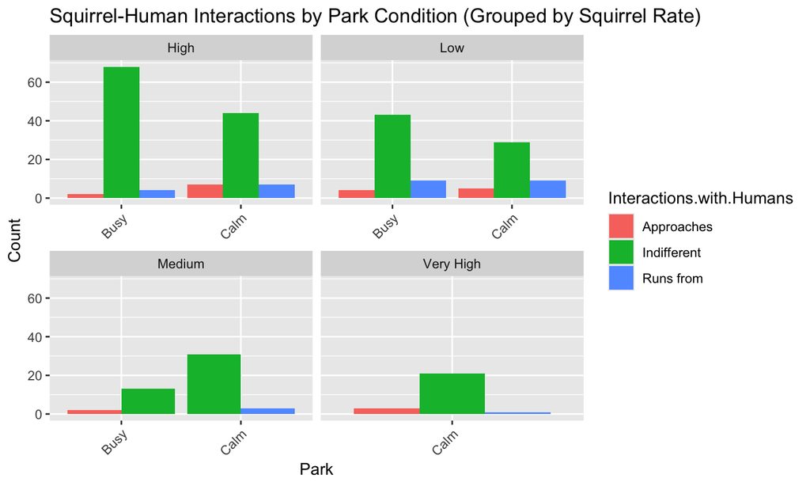

## Atmosphere/ambiance: Heatmap

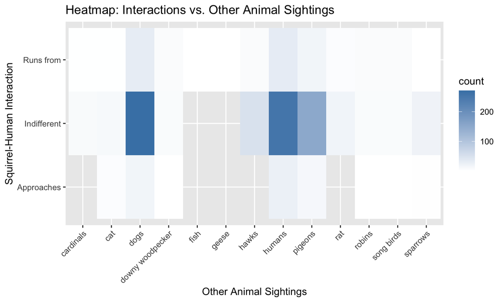

## Environment: Heatmap

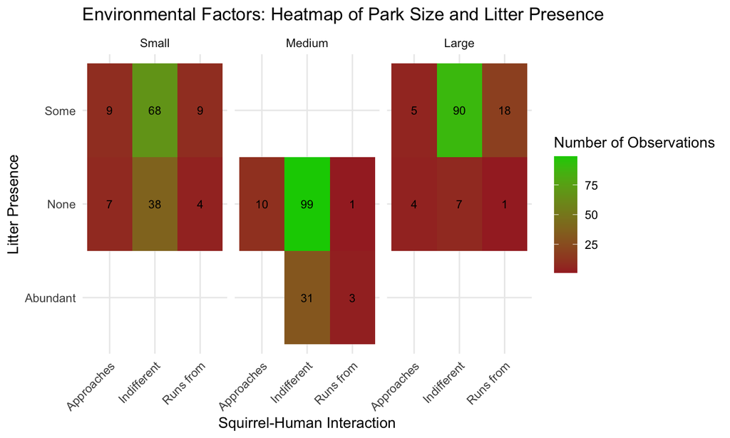

## Environment: Heatmap (cont.)

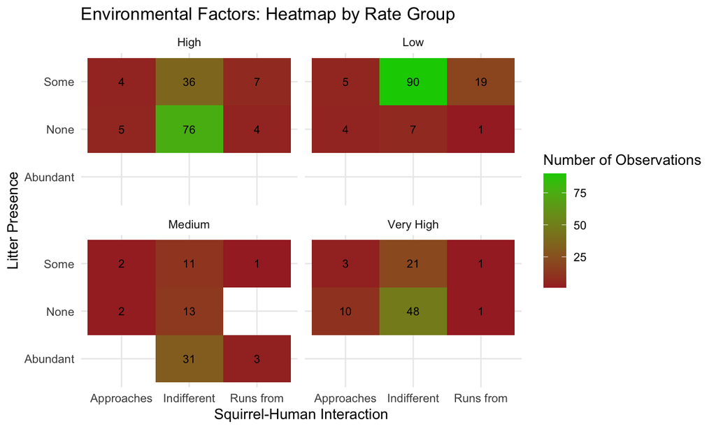

## Squirrel Map: Shiny App

- Parks in Lower Manhattan tend to be busier than parks in Upper Manhattan.
  - We also observe that squirrels in Lower Manhattan are more likely to approach humans than those in Upper Manhattan.
- Many had missing data for longitude and latitude, so we estimated using different methods.
- https://admedeiros.shinyapps.io/Final_Project/